# softmax

## 1.sigmoid

二分类首先想到的是逻辑回归算法，将线性模型输出的实数域映射到[0,1]表示概率分布的有效空间。其中sigmoid函数$f(x) = \frac{1}{1+e^{-x}}$可以实现这样的功能，下面绘制sigmoid函数图：

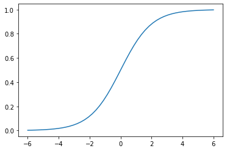

```python
import matplotlib.pyplot as plt
import numpy as np

x = np.linspace(-6, 6)
y = 1.0 / (1 + np.exp(-x))
plt.plot(x, y)
plt.show()
```

对于二分类问题，除了可以使用单个输出节点表示事件A发生的概率P(A|x)外，还可以分布预测P(A|x)和$P(\bar{A}|x)$，并满足约束：$P(A|x) + P(\bar{A}|x) = 1$，其中$\bar{A}$表示事件A的对立事件。  
两个节点输出的二分类相比于单个节点输出的二分类多了一个$P(A|x) + P(\bar{A}|x) = 1$的约束条件，这个约束条件将输出节点的输出值变成了一个 概率分布，简单来说各个输出节点的输出值范围映射到[0,1]，并且约束各个输出节点的输出值的和为1。**当然可以将输出为两个节点的二分类推广成拥有n个输出节点的n分类问题。**  
**有没有将各个输出节点的输出值范围映射到[0,1]，并且约束各个输出节点的输出值和为1的函数呢？**这个函数就是Softmax函数

## 2.什么是Softmax？

对于文本分类来说，一篇文章或多或少包含着各种主题信息，期望得到文章对于每个可能的文本类别的概率（置信度），可以简单理解成书于对应类别的可信度。所以此时用到了soft的概念，Softmax的含义就在于不再唯一的确定某一个最大值，而是为每个输出分类的结果都赋予一个概率值，表示属于莫哥类别的可能性。  
Softmax函数的定义：$Softmax(z_i) = \frac{e^{z_i}}{\sum_{c=1}^C e^{z_c}}$，其中$z_i$为第i个节点的输出值，C为输出节点的个数，即分类的类别个数。  
**通过Softmax函数就可以将多分类的输出值转换为范围在[0,1]和为1的概率分布。**  
引入指数函数对于Softmax函数是把双刃剑，即得到了优点也暴露了缺点：

### 2.1 引入指数形式的优点

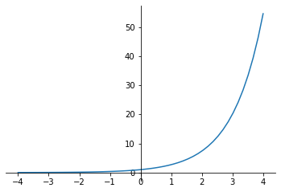

```python
x = np.linspace(-4, 4)
y = np.exp(x)
plt.plot(x, y)
ax = plt.gca()
#使用spines设置边框，共有（"left","right","top","bottom"）四种选项，使用set_color()设置颜色
ax.spines["right"].set_color("none")
ax.spines["top"].set_color("none")
#将底部边框放大y=0的位置
ax.spines["bottom"].set_position(("data", 0))
ax.spines["left"].set_position(("data", 0))
plt.show()
```

指数函数曲线呈现递增趋势，最重要的斜率逐渐增大，也就是说在x轴上一个很小的变化，可以导致y轴上很大的变化。这种函数曲线能够将输出的数字拉开距离。 假设拥有3个输出节点的输出值$z_1, z_2, z_3$为[2, 3, 5]，首先尝试不使用指数函数$\frac{z_i}{\sum_{c=1}^3 z_c}$， 接下来使用指数函数的softmax函数计算。

```
tf version: 2.5.0
b1: [0.2 0.3 0.5]
b2: [0.04201007 0.11419519 0.8437947 ]
```

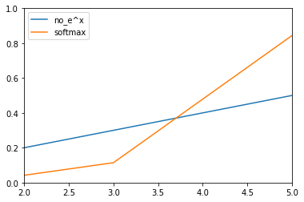

```python
import tensorflow as tf

print("tf version: {}".format(tf.__version__))

a = tf.constant([2, 3, 5], dtype=tf.float32)

# 不使用指数
b1 = a / tf.reduce_sum(a)
print("b1: {}".format(b1))

# 使用指数softmax
b2 = tf.nn.softmax(a)
print("b2: {}".format(b2))

# 使用matplotlib绘图
plt.xlim(2,5) #设置x轴的范围为[0,1]
plt.ylim(0,1) #同上
plt.plot(a, b1)
plt.plot(a, b2)
plt.legend(['no_e^x','softmax']) #打出图例
plt.show()
```

结果还是挺明显的，经过使用指数形式的softmax函数能够将差距大的数值距离拉的更大。在深度学习中通常使用方向传播求梯度进而使用梯度下降进行参数更新的过程，而指数函数在求导的时候比较方便。比如$(e^x)^\prime = e^x$

### 2.2 引入指数形式的缺点

指数函数的曲线斜率逐渐增大虽然能够将输出值拉开距离，但是也带来了缺点，当$z_i$值非常大的话，计算得到的数值也会变得非常大，数值可能会溢出。

```python
import numpy as np

scores = np.array([123, 456, 789])
softmax = np.exp(scores) / np.sum(np.exp(scores))
print(softmax)
```

```
[ 0.  0. nan]
```

```python
scores2 = tf.constant([123, 456, 789], dtype=tf.float32)
softmax2 = tf.nn.softmax(scores2)
print(softmax2)
```

```
tf.Tensor([0. 0. 1.], shape=(3,), dtype=float32)
```

当然针对数值溢出有其对应的优化方法，将每一个输出值减去输出值中最大的值。  
$D = max(z)$  
$softmax(z_i) = \frac{e^{z_i-D}}{\sum_{c=1}^C e^{z_c -D}}$

```python
import numpy as np

scores = np.array([123, 456, 789])
scores -= np.max(scores)
p = np.exp(scores) / np.sum(np.exp(scores))
print(p)
```

```
[5.75274406e-290 2.39848787e-145 1.00000000e+000]
```

这里需要注意一下，当使用Softmax函数作为输出节点的激活函数的时候，一般使用交叉熵作为损失函数。由于Softmax函数的数值计算过程中，很容易因为输出节点的输出值比较大而发生数值溢出的现象，在计算交叉熵的时候也可能会出现数值溢出的问题。为了数值计算的稳定性，TensorFlow提供了一个统一的接口，将Softmax与交叉熵损失函数同时实现，同时也处理了数值不稳定的异常，使用TensorFlow深度学习框架的时候，一般推荐使用这个统一的接口，避免分开使用Softmax函数与交叉熵损失函数。

```python
import tensorflow as tf

tf.keras.losses.categorical_crossentropy(y_true, y_pred, from_logits=False)
```

其中，y_ture代表one-hot编码后的真实标签，y_pred表示网络的实际预测值：

- 当from_logits设置为True时，y_pred表示未经Softmax函数的输出值
- 当from_logits设置为False时，y_pred表示为经过Softmax函数后的输出值

推荐使用将from_logits参数设置为True的统一接口。